# Sensitivity Analyses

Cecilia Albert-Black

2026-01-21

# Objectives

BLM assumptions evaluated (two paired scenarios)

- **Carbonate charge balance**
  - Baseline: Closed system, measured DIC as input
  - Perturbed: Open system, no DIC input, alkalinity estimated by charge balance (assuming in equilibrium with atmospheric partial pressure)
- **Humic acid fraction of DOC**
  - Baseline: HA = 10% (suggested by the BLM manual)
  - Perturbed: HA = 80%

# 1. Setup

We will merge BLM output variables from the baseline conditions (closed system + HA 10%) and the perturbed scenarios (open system + HA 10% and closed system + HA 80%) which are currently organized into separate tabs within the Bioavailability Master Spreadsheet.

First, we’ll load all the necessary packages

```r
library(readxl)
library(dplyr)
```

```r
library(tidyr)
library(stringr)
library(ggplot2)
library(e1071)
```

Next, we’ll set the working directory and import each dataset as it’s own object

```r
library(readxl)

# -------------------------------------------------
# 1) Set working directory
# -------------------------------------------------
setwd("C:/Users/q4q/OneDrive - Oak Ridge National Laboratory/Research/Bioavailability Project/1. Spatial Assessment/Data/Spatial Assessment of Bioavailability Project/6. Sensitivity analyses")

# -------------------------------------------------
# 2) Store file paths once (so you don't repeat them)
# -------------------------------------------------
file_master3 <- "C:/Users/q4q/OneDrive - Oak Ridge National Laboratory/Research/Bioavailability Project/1. Spatial Assessment/Data/Spatial Assessment of Bioavailability Project/5. Statistical data analysis/Bioavailability_Master_Spreadsheet_Clean_3.xlsx"

file_master2 <- "C:/Users/q4q/OneDrive - Oak Ridge National Laboratory/Research/Bioavailability Project/1. Spatial Assessment/Data/Spatial Assessment of Bioavailability Project/4. Exploratory data analysis/Bioavailability_Master_Spreadsheet_Clean_2.xlsx"
```

# 2. Data organization

Now we’ll read each file and create the following scenarios as their own objects

- ha_10_cs
- ha_10_os
- ha_80_cs

```r
read_scenario <- function(path, sheet, scenario_label) {
  read_excel(path, sheet = sheet) %>%
    mutate(Scenario = scenario_label) %>%
    relocate(Scenario, .before = 1)
}

ha_10_cs <- read_scenario(file_master3, "HA 10% Closed System", "HA 10% Closed System")
ha_10_os <- read_scenario(file_master2, "HA 10% Open System",   "HA 10% Open System")
ha_80_cs <- read_scenario(file_master2, "HA 80% Closed System", "HA 80% Closed System")
```

Now we’ll add typology to each scenario (ha_10_cs already has it)

```r
typology_lookup <- ha_10_cs %>%
  select(Sample_ID, Typology) %>%
  distinct()

ha_10_os <- ha_10_os %>% left_join(typology_lookup, by = "Sample_ID")
ha_80_cs <- ha_80_cs %>% left_join(typology_lookup, by = "Sample_ID")

# quick sanity check (should be character(0))
setdiff(ha_10_os$Sample_ID, ha_10_cs$Sample_ID)
```

```
## character(0)
```

```r
setdiff(ha_80_cs$Sample_ID, ha_10_cs$Sample_ID)
```

```
## character(0)
```

Stack each scenario to create one long dataset (dat_long)

```r
dat_long <- bind_rows(ha_10_cs, ha_10_os, ha_80_cs)
head(dat_long)
```

```
## # A tibble: 6 × 440
##   Scenario        Typology Sample_ID Site  Date                Regime Flow_state
##   <chr>           <chr>    <chr>     <chr> <dttm>              <chr>  <chr>
## 1 HA 10% Closed … Develop… WaDE_62   MTN1… 2023-06-23 00:00:00 NonPe… Flowing
## 2 HA 10% Closed … Main St… WaDE_63   EFK1… 2023-06-23 00:00:00 Peren… Flowing
## 3 HA 10% Closed … Tributa… WaDE_64   MTN4  2023-06-23 00:00:00 Peren… Flowing
## 4 HA 10% Closed … Pooled … WaDE_65   MTN2  2023-06-23 00:00:00 NonPe… Pooled
## 5 HA 10% Closed … Tributa… WaDE_66   MCA3… 2023-06-23 00:00:00 NonPe… Flowing
## 6 HA 10% Closed … Tributa… WaDE_67   MCA3… 2023-06-23 00:00:00 NonPe… Flowing
## # ℹ 433 more variables: Network <chr>, Relative_elevation_m <dbl>,
## #   Dist_from_EFPC_km <dbl>, Drainage_area_km2 <dbl>, Developed_lulc <dbl>,
## #   Type <chr>, Development <chr>, Distance_from_EFPC <chr>,
## #   Drainage_area <chr>, Orientation <chr>, Relative_elevation <chr>, pH <dbl>,
## #   Temp_C <dbl>, DOC_uM <dbl>, Ca_uM <dbl>, Mg_uM <dbl>, Na_uM <dbl>,
## #   K_uM <dbl>, SO4_uM <dbl>, Cl_uM <dbl>, DIC_uM <dbl>, Zn_uM <dbl>,
## #   Cu_uM <dbl>, Free_Zn_M <dbl>, ZnOH_M <dbl>, Zn_OH_2_M <dbl>, …
```

# 3. Define response variables + log-transformed variables

```r
id_cols <- c("Sample_ID", "Typology", "Scenario")

response_vars <- c(

  # Zn aqueous species
  "Free_Zn_nM",
  "ZnOH_nM",
  "Zn_OH_2_nM",
  "ZnCO3_nM",
  "ZnHCO3_nM",
  "ZnSO4_nM",
  "ZnCl_nM",
  "ZnS_nM",
  "TOrg_Zn_nM",

  # Zn biotic ligand binding
  "BL_Zn_nmol_g_Zn",
  "BL_Ca_nmol_g_Zn",
  "BL_H_nmol_g_Zn",
  "BL_Mg_nmol_g_Zn",
  "BL_Na_nmol_g_Zn",
  "BL_ZnOH_nmol_g_Zn",

  # Cu aqueous species
  "CuOH_nM",
  "CuSO4_nM",
  "CuCO3_nM",
  "CuCl_nM",
  "CuHCO3_nM",
  "Cu_CO3_2_nM",
  "Free_Cu_nM",
  "Cu_OH_2_nM",
  "TOrg_Cu_nM",

  # Cu biotic ligand binding
  "BL_Cu_nmol_g_Cu",
  "BL_Ca_nmol_g_Cu",
  "BL_H_nmol_g_Cu",
  "BL_Mg_nmol_g_Cu",
  "BL_Na_nmol_g_Cu",
  "BL_CuOH_nmol_g_Cu"
)

dat_long <- dat_long %>%
  mutate(across(all_of(response_vars), log, .names = "log_{.col}"))

log_response_vars <- paste0("log_", response_vars)
```

# 4. Sensitivity calculations

Using one function, we’ll create a paired dataset and calculate the delta, percent change, and log response ratio (LRR) for each variable

## I. Helper functions

### a. Create wide dataset

```r
make_pair_wide <- function(dat, scenarios, short_labels = c("Baseline", "Perturbed"), vars) {
  dat %>%
    filter(Scenario %in% scenarios) %>%
    mutate(Scenario_short = recode(Scenario,
                                  !!scenarios[1] := short_labels[1],
                                  !!scenarios[2] := short_labels[2])) %>%
    select(Sample_ID, Typology, Scenario_short, all_of(vars)) %>%
    pivot_wider(
      names_from = Scenario_short,
      values_from = all_of(vars),
      names_sep = "_"
    )
}
```

### b. Calculate SA metrics

- **Delta**: baseline − perturbed (matches your carbonate delta)
- **Percent change**: (perturbed − baseline) / baseline * 100 (matches your code)
- **LRR**: log10(perturbed) − log10(baseline)

```r
library(dplyr)
library(tibble)

compute_sensitivity <- function(pair_wide, vars, baseline, perturbed) {

  # Helper to build the expected wide column names
  base_cols <- paste0(vars, "_", baseline)
  pert_cols <- paste0(vars, "_", perturbed)

  # Safety check: stop early with a clear message if something is missing
  missing_cols <- setdiff(c(base_cols, pert_cols), names(pair_wide))
  if (length(missing_cols) > 0) {
    stop("These columns are missing from pair_wide:\n", paste(missing_cols, collapse = ", "))
  }

  # -------------------------------------------------
  # 1) Delta: baseline - perturbed
  # -------------------------------------------------
  delta_df <- tibble(
    Sample_ID = pair_wide$Sample_ID,
    Typology  = pair_wide$Typology
  ) %>%
    bind_cols(
      as_tibble(setNames(
        lapply(vars, function(v) {
          pair_wide[[paste0(v, "_", baseline)]] - pair_wide[[paste0(v, "_", perturbed)]]
        }),
        paste0("delta_", vars)
      ))
    )

  # -------------------------------------------------
  # 2) Percent change: (perturbed - baseline) / baseline * 100
  # -------------------------------------------------
  pct_df <- tibble(
    Sample_ID = pair_wide$Sample_ID,
    Typology  = pair_wide$Typology
  ) %>%
    bind_cols(
      as_tibble(setNames(
        lapply(vars, function(v) {
          b <- pair_wide[[paste0(v, "_", baseline)]]
          p <- pair_wide[[paste0(v, "_", perturbed)]]

          ifelse(!is.na(b) & b != 0, (p - b) / b * 100, NA_real_)
        }),
        paste0("pct_", vars)
      ))
    )

  # -------------------------------------------------
  # 3) Log response ratio: log10(perturbed) - log10(baseline)
  # -------------------------------------------------
  lrr_df <- tibble(
    Sample_ID = pair_wide$Sample_ID,
    Typology  = pair_wide$Typology
  ) %>%
    bind_cols(
      as_tibble(setNames(
        lapply(vars, function(v) {
          b <- pair_wide[[paste0(v, "_", baseline)]]
          p <- pair_wide[[paste0(v, "_", perturbed)]]

          ifelse(!is.na(b) & !is.na(p) & b > 0 & p > 0, log10(p) - log10(b), NA_real_)
        }),
        paste0("dlog10_", vars)
      ))
    )

  # Return everything neatly
  list(pair_wide = pair_wide, delta = delta_df, pct = pct_df, lrr = lrr_df)
}
```

### c. Wilcoxon tests

```r
# ------------------------------------------------------------
# Helper 1: Run paired Wilcoxon tests for ONE comparison
# ------------------------------------------------------------
run_wilcox_paired <- function(dat_long, baseline_scn, perturbed_scn, log_vars) {

  # 1) Make a long table of log variables for the two scenarios
  long_dat <- dat_long %>%
    filter(Scenario %in% c(baseline_scn, perturbed_scn)) %>%
    select(Sample_ID, Scenario, all_of(log_vars)) %>%
    pivot_longer(
      cols = all_of(log_vars),
      names_to = "Variable",
      values_to = "Log_Value"
    ) %>%
    mutate(
      Variable = str_remove(Variable, "^log_"),
      Metal = case_when(
        str_detect(Variable, "Zn") ~ "Zn",
        str_detect(Variable, "Cu") ~ "Cu",
        TRUE ~ NA_character_
      )
    ) %>%
    filter(!is.na(Metal))

  # 2) Pivot wide so each Sample_ID has baseline and perturbed side-by-side
  wide_dat <- long_dat %>%
    select(Sample_ID, Scenario, Variable, Metal, Log_Value) %>%
    pivot_wider(names_from = Scenario, values_from = Log_Value)

  # 3) Run paired Wilcoxon test per Variable
  wilcox_tbl <- wide_dat %>%
    group_by(Variable, Metal) %>%
    summarise(
      n_pairs = sum(!is.na(.data[[baseline_scn]]) & !is.na(.data[[perturbed_scn]])),
      p_value = wilcox.test(
        x = .data[[baseline_scn]],
        y = .data[[perturbed_scn]],
        paired = TRUE,
        exact = FALSE
      )$p.value,
      .groups = "drop"
    ) %>%
    mutate(
      sig_label = case_when(
        p_value <= 0.001 ~ "***",
        p_value <= 0.01  ~ "**",
        p_value <= 0.05  ~ "*",
        TRUE ~ ""
      )
    )

  list(long_dat = long_dat, wilcox_tbl = wilcox_tbl)
}
```

## III. Carbonate assumption SA

### a. Paired dataset

```r
dic_pair <- make_pair_wide(
  dat = dat_long,
  scenarios = c("HA 10% Closed System", "HA 10% Open System"),
  short_labels = c("Closed", "Open"),
  vars = response_vars
)

dic_sa <- dic_pair

dic_results <- compute_sensitivity(
  pair_wide = dic_sa,
  vars = response_vars,
  baseline = "Closed",
  perturbed = "Open"
)

dic_delta  <- dic_results$delta
dic_pct    <- dic_results$pct
dic_dlog10 <- dic_results$lrr
```

### b. Summary statistics

```r
summarise_metric <- function(metric_df, prefix, vars) {
  metric_df %>%
    select(starts_with(prefix)) %>%
    setNames(vars) %>%                     # drop prefix in column names
    pivot_longer(everything(), names_to = "Variable", values_to = "Value") %>%
    group_by(Variable) %>%
    summarise(
      Mean   = mean(Value, na.rm = TRUE),
      Median = median(Value, na.rm = TRUE),
      Q1     = quantile(Value, 0.25, na.rm = TRUE),
      Q3     = quantile(Value, 0.75, na.rm = TRUE),
      IQR    = IQR(Value, na.rm = TRUE),
      .groups = "drop"
    ) %>%
    mutate(
      Metal = case_when(
        str_detect(Variable, "Zn") ~ "Zn",
        str_detect(Variable, "Cu") ~ "Cu",
        TRUE ~ NA_character_
      )
    ) %>%
    filter(!is.na(Metal)) %>%
    group_by(Metal) %>%
    arrange(Median, .by_group = TRUE) %>%
    mutate(
      Variable = factor(Variable, levels = Variable),
      Rank = row_number()
    ) %>%
    ungroup()
}

# Tables to help plot
plot_pct_dic <- summarise_metric(dic_pct, prefix = "pct_", vars = response_vars)
plot_lrr_dic <- summarise_metric(dic_dlog10, prefix = "dlog10_", vars = response_vars)
```

Save summary statistics

```r
library(openxlsx)

# Create a new workbook for flowing tributary sites
wb <- createWorkbook("Sensitivity_analysis_dic_assumptions.xlsx")

# Create sheet if it does NOT exist
if(!"Percent Change" %in% names(wb)) {
  addWorksheet(wb, "Percent Change")
}

# Write your new table
writeData(wb, "Percent Change", plot_pct_dic)

# Create sheet if it does NOT exist
if(!"LRR" %in% names(wb)) {
  addWorksheet(wb, "LRR")
}

# Write your new table
writeData(wb, "LRR", plot_lrr_dic)

# Save the workbook (overwrite)
saveWorkbook(wb, "Sensitivity_analysis_dic_assumptions.xlsx", overwrite = TRUE)
```

### c. Plots (percent change + LRR)

Faceted

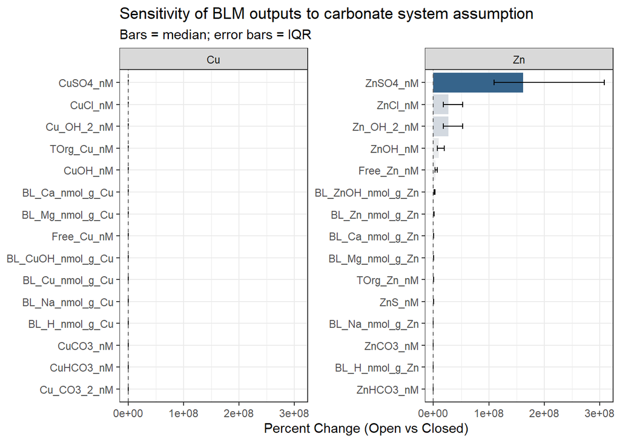

```r
library(ggplot2)

plot_summary_bars <- function(df, xlab, title, subtitle, fill_name) {
  ggplot(df, aes(y = Variable)) +
    geom_col(aes(x = Median, fill = Median)) +
    geom_errorbarh(aes(xmin = Q1, xmax = Q3), height = 0.25) +
    geom_vline(xintercept = 0, linetype = "dashed", color = "grey40") +
    facet_wrap(~ Metal, scales = "free_y") +
    scale_fill_gradient2(
      low = "red3", mid = "grey95", high = "steelblue4",
      midpoint = 0,
      name = fill_name
    ) +
    labs(x = xlab, y = NULL, title = title, subtitle = subtitle) +
    theme_bw() +
    guides(fill = "none")
}

# Percent change plot
p_pct_dic <- plot_summary_bars(
  plot_pct_dic,
  xlab = "Percent Change (Open vs Closed)",
  title = "Sensitivity of BLM outputs to carbonate system assumption",
  subtitle = "Bars = median; error bars = IQR",
  fill_name = "% Change"
)

# LRR plot
p_lrr_dic <- plot_summary_bars(
  plot_lrr_dic,
  xlab = "Log Response Ratio (Open vs Closed)",
  title = "Sensitivity of BLM outputs to carbonate system assumption",
  subtitle = "Bars = median; error bars = IQR",
  fill_name = "Median LRR"
)

p_pct_dic
```

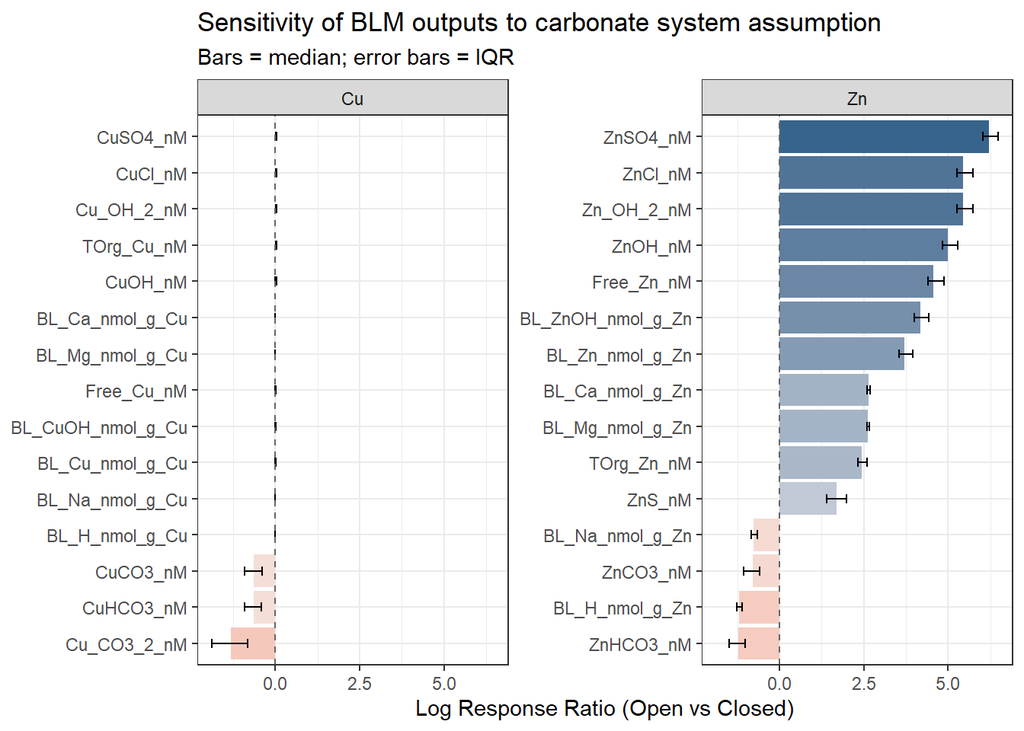

```r
p_lrr_dic
```

Save

```r
# Define output directory
out_dir <- "Plots of DIC SA"

# Create folder if it doesn't exist
if (!dir.exists(out_dir)) {
  dir.create(out_dir, recursive = TRUE)
}

# Save plot
ggsave(
  filename = file.path(out_dir, "Percent_Change_DIC_SA.png"),
  plot = p_pct_dic,
  width = 10,
  height = 8,
  units = "in",
  dpi = "print"
)

# Save plot
ggsave(
  filename = file.path(out_dir, "LRR_DIC_SA.png"),
  plot = p_lrr_dic,
  width = 10,
  height = 8,
  units = "in",
  dpi = "print"
)
```

Individual: percent change

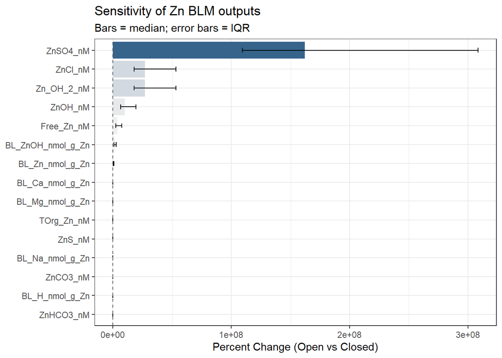

```r
plot_summary_single <- function(df, metal, xlab, title, subtitle, fill_name) {

  df_one <- df %>% filter(Metal == metal)

  ggplot(df_one, aes(y = Variable)) +
    geom_col(aes(x = Median, fill = Median)) +
    geom_errorbarh(aes(xmin = Q1, xmax = Q3), height = 0.25) +
    geom_vline(xintercept = 0, linetype = "dashed", color = "grey40") +
    scale_fill_gradient2(
      low = "red3", mid = "grey95", high = "steelblue4",
      midpoint = 0,
      name = fill_name
    ) +
    labs(x = xlab, y = NULL, title = title, subtitle = subtitle) +
    theme_bw() +
    guides(fill = "none")
}

plot_pct_zn <- plot_summary_single(
  plot_pct_dic,
  metal = "Zn",
  xlab = "Percent Change (Open vs Closed)",
  title = "Sensitivity of Zn BLM outputs",
  subtitle = "Bars = median; error bars = IQR",
  fill_name = "% Change"
)

plot_pct_cu <- plot_summary_single(
  plot_pct_dic,
  metal = "Cu",
  xlab = "Percent Change (Open vs Closed)",
  title = "Sensitivity of Cu BLM outputs",
  subtitle = "Bars = median; error bars = IQR",
  fill_name = "% Change"
)

plot_pct_zn
```

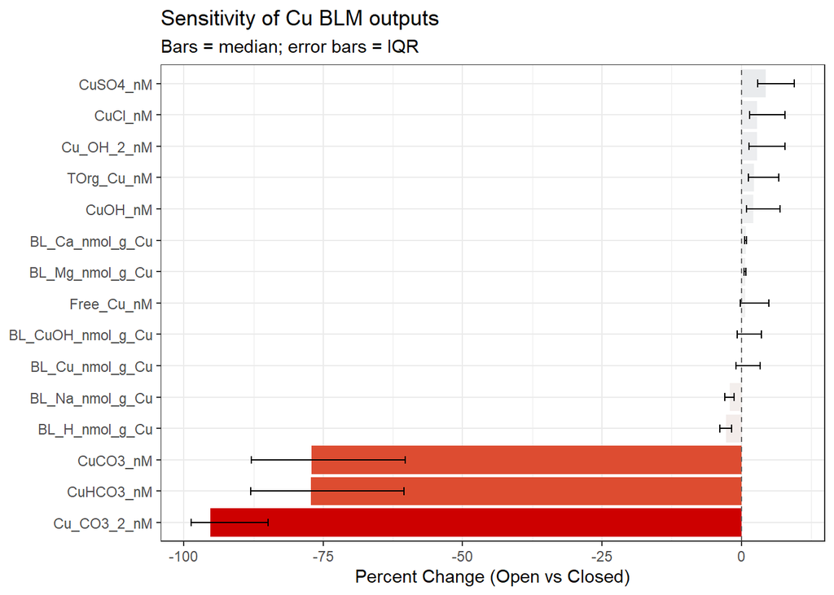

```r
plot_pct_cu
```

Save plots

```r
# Save plot
ggsave(
  filename = file.path(out_dir, "Percent_Change_Zn_DIC_SA.png"),
  plot = plot_pct_zn,
  width = 10,
  height = 8,
  units = "in",
  dpi = "print"
)

# Save plot
ggsave(
  filename = file.path(out_dir, "Percent_Change_Cu_DIC_SA.png"),
  plot = plot_pct_cu,
  width = 10,
  height = 8,
  units = "in",
  dpi = "print"
)
```

Individual: LRR

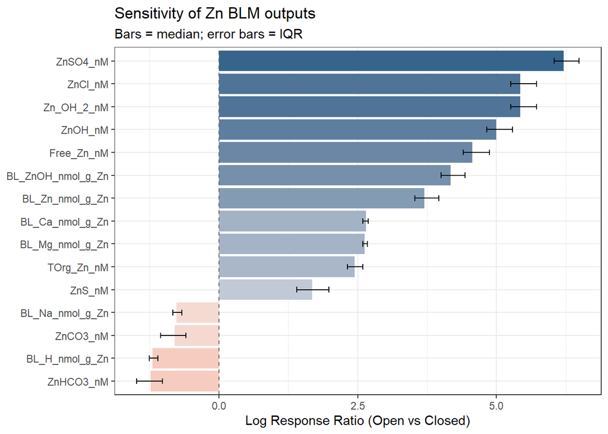

```r
plot_lrr_zn <- plot_summary_single(
  plot_lrr_dic,
  metal = "Zn",
  xlab = "Log Response Ratio (Open vs Closed)",
  title = "Sensitivity of Zn BLM outputs",
  subtitle = "Bars = median; error bars = IQR",
  fill_name = "LRR"
)

plot_lrr_cu <- plot_summary_single(
  plot_lrr_dic,
  metal = "Cu",
  xlab = "Log Response Ratio (Open vs Closed)",
  title = "Sensitivity of Cu BLM outputs",
  subtitle = "Bars = median; error bars = IQR",
  fill_name = "LRR"
)

plot_lrr_zn
```

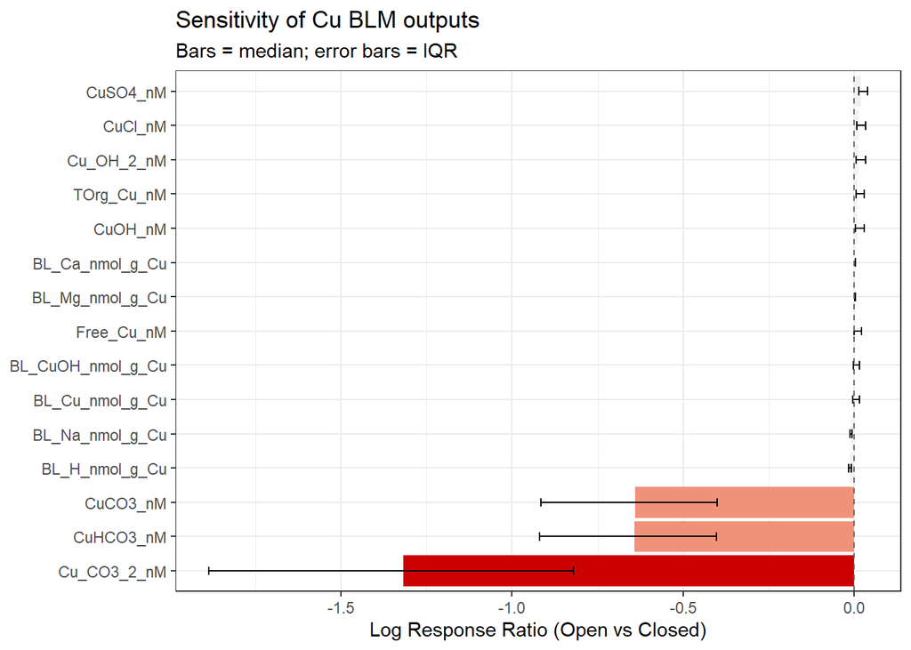

```r
plot_lrr_cu
```

Save plots

```r
# Save plot
ggsave(
  filename = file.path(out_dir, "LRR_Zn_DIC_SA.png"),
  plot = plot_lrr_zn,
  width = 10,
  height = 8,
  units = "in",
  dpi = "print"
)

# Save plot
ggsave(
  filename = file.path(out_dir, "LRR_Cu_DIC_SA.png"),
  plot = plot_lrr_cu,
  width = 10,
  height = 8,
  units = "in",
  dpi = "print"
)
```

### d. Wilcoxon paired tests

```r
baseline_scn <- "HA 10% Closed System"
dic_pert_scn <- "HA 10% Open System"

dic_wilcox <- run_wilcox_paired(
  dat_long      = dat_long,
  baseline_scn  = baseline_scn,
  perturbed_scn = dic_pert_scn,
  log_vars      = log_response_vars
)

# Add p-values + sig labels back onto the plotting data
dic_plot_dat_sig <- dic_wilcox$long_dat %>%
  left_join(dic_wilcox$wilcox_tbl %>% select(Variable, p_value, n_pairs, sig_label),
            by = "Variable")

# View
View(dic_plot_dat_sig)
```

Save table

```r
library(openxlsx)

# 1) Load the existing workbook
wb <- loadWorkbook("Sensitivity_analysis_dic_assumptions.xlsx")

# Create sheet if it does NOT exist
if(!"Wilcoxon tests" %in% names(wb)) {
  addWorksheet(wb, "Wilcoxon tests")
  }

# Write your new table
writeData(wb, "Wilcoxon tests", dic_plot_dat_sig)

# Save the workbook (overwrite)
saveWorkbook(wb, "Sensitivity_analysis_dic_assumptions.xlsx", overwrite = TRUE)
```

## IV. Humic acid assumption SA

### a. Paired dataset

```r
ha_pair <- make_pair_wide(
  dat = dat_long,
  scenarios = c("HA 10% Closed System", "HA 80% Closed System"),
  short_labels = c("Low HA", "High HA"),
  vars = response_vars
)

ha_sa <- ha_pair

ha_results <- compute_sensitivity(
  pair_wide = ha_sa,
  vars = response_vars,
  baseline = "Low HA",
  perturbed = "High HA"
)

ha_delta  <- ha_results$delta
ha_pct    <- ha_results$pct
ha_dlog10 <- ha_results$lrr
```

### b. Summary statistics

```r
# Tables to help plot (using summarize_metric helper function from previous section)

plot_pct_ha <- summarise_metric(ha_pct, prefix = "pct_", vars = response_vars)
plot_lrr_ha <- summarise_metric(ha_dlog10, prefix = "dlog10_", vars = response_vars)
```

Save to excel

```r
library(openxlsx)

# Create a new workbook for flowing tributary sites
wb <- createWorkbook("Sensitivity_analysis_ha_assumptions.xlsx")

# Create sheet if it does NOT exist
if(!"Percent Change" %in% names(wb)) {
  addWorksheet(wb, "Percent Change")
}

# Write your new table
writeData(wb, "Percent Change", plot_pct_ha)

# Create sheet if it does NOT exist
if(!"LRR" %in% names(wb)) {
  addWorksheet(wb, "LRR")
}

# Write your new table
writeData(wb, "LRR", plot_lrr_ha)

# Save the workbook (overwrite)
saveWorkbook(wb, "Sensitivity_analysis_ha_assumptions.xlsx", overwrite = TRUE)
```

### c. Plots (percent change + LRR)

Faceted

```r
library(ggplot2)

# Using plot_summary_bars helper function created in previous section to plot

# Percent change plot
p_pct_ha <- plot_summary_bars(
  plot_pct_ha,
  xlab = "Percent Change (Low HA vs High HA)",
  title = "Sensitivity of BLM outputs to varying humic acid assumption",
  subtitle = "Bars = median; error bars = IQR",
  fill_name = "% Change"
)

# LRR plot
p_lrr_ha <- plot_summary_bars(
  plot_lrr_ha,
  xlab = "Log Response Ratio (Low HA vs High HA)",
  title = "Sensitivity of BLM outputs to varying humic acid assumption",
  subtitle = "Bars = median; error bars = IQR",
  fill_name = "Median LRR"
)
```

Save plots

```r
# Define output directory
out_dir <- "Plots of HA SA"

# Create folder if it doesn't exist
if (!dir.exists(out_dir)) {
  dir.create(out_dir, recursive = TRUE)
}

# Save plot
ggsave(
  filename = file.path(out_dir, "Percent_Change_DIC_SA.png"),
  plot = p_pct_ha,
  width = 10,
  height = 8,
  units = "in",
  dpi = "print"
)

# Save plot
ggsave(
  filename = file.path(out_dir, "LRR_DIC_SA.png"),
  plot = p_lrr_ha,
  width = 10,
  height = 8,
  units = "in",
  dpi = "print"
)
```

Individual: percent change

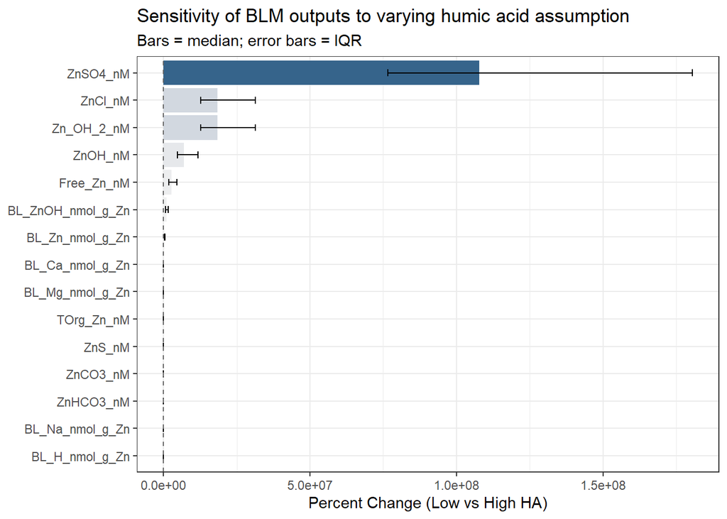

```r
plot_pct_zn <- plot_summary_single(
  plot_pct_ha,
  metal = "Zn",
  xlab = "Percent Change (Low vs High HA)",
  title = "Sensitivity of BLM outputs to varying humic acid assumption",
  subtitle = "Bars = median; error bars = IQR",
  fill_name = "% Change"
)

plot_pct_cu <- plot_summary_single(
  plot_pct_ha,
  metal = "Cu",
  xlab = "Percent Change (Low vs High HA)",
  title = "Sensitivity of BLM outputs to varying humic acid assumption",
  subtitle = "Bars = median; error bars = IQR",
  fill_name = "% Change"
)

plot_pct_zn
```

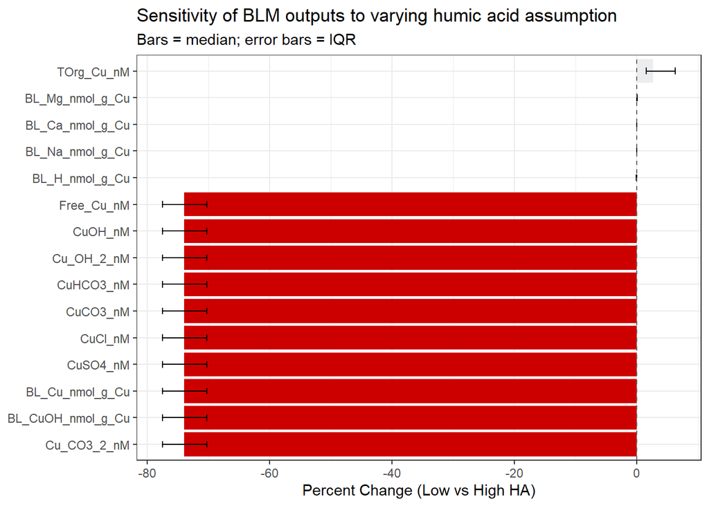

```r
plot_pct_cu
```

Save plots

```r
# Save plot
ggsave(
  filename = file.path(out_dir, "Percent_Change_Zn_HA_SA.png"),
  plot = plot_pct_zn,
  width = 10,
  height = 8,
  units = "in",
  dpi = "print"
)

# Save plot
ggsave(
  filename = file.path(out_dir, "Percent_Change_Cu_HA_SA.png"),
  plot = plot_pct_cu,
  width = 10,
  height = 8,
  units = "in",
  dpi = "print"
)
```

Individual: LRR

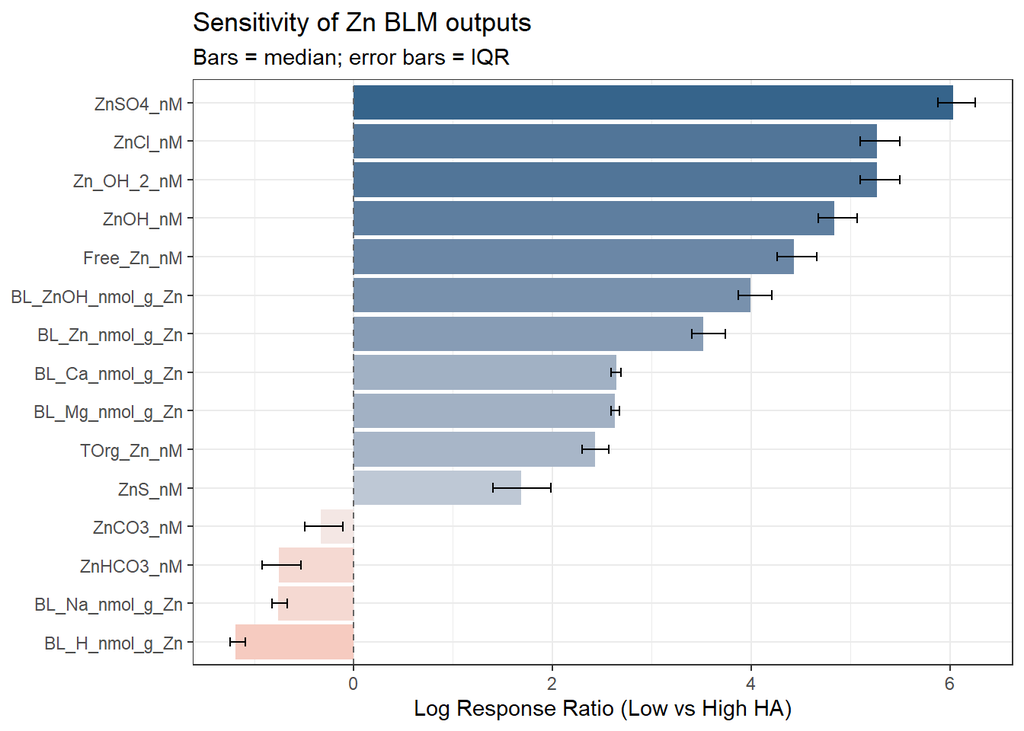

```r
plot_lrr_zn <- plot_summary_single(
  plot_lrr_ha,
  metal = "Zn",
  xlab = "Log Response Ratio (Low vs High HA)",
  title = "Sensitivity of Zn BLM outputs",
  subtitle = "Bars = median; error bars = IQR",
  fill_name = "LRR"
)

plot_lrr_cu <- plot_summary_single(
  plot_lrr_ha,
  metal = "Cu",
  xlab = "Log Response Ratio (Low vs High HA)",
  title = "Sensitivity of Cu BLM outputs",
  subtitle = "Bars = median; error bars = IQR",
  fill_name = "LRR"
)

plot_lrr_zn
```

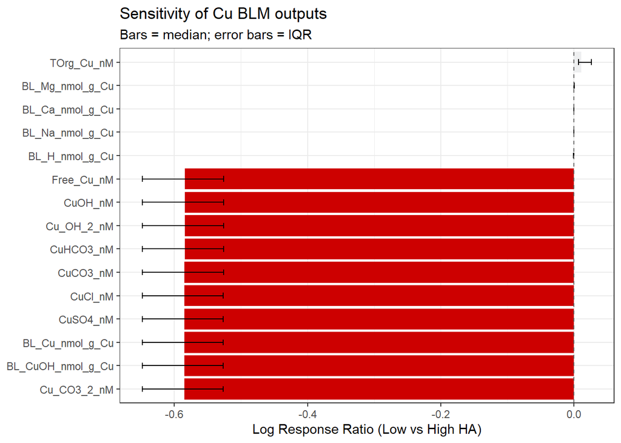

```r
plot_lrr_cu
```

Save plots

```r
# Save plot
ggsave(
  filename = file.path(out_dir, "LRR_Zn_HA_SA.png"),
  plot = plot_lrr_zn,
  width = 10,
  height = 8,
  units = "in",
  dpi = "print"
)

# Save plot
ggsave(
  filename = file.path(out_dir, "LRR_Cu_HA_SA.png"),
  plot = plot_lrr_cu,
  width = 10,
  height = 8,
  units = "in",
  dpi = "print"
)
```

### d. Wilcoxon paired tests

```r
baseline_scn <- "HA 10% Closed System"
ha_pert_scn <- "HA 80% Closed System"

ha_wilcox <- run_wilcox_paired(
  dat_long      = dat_long,
  baseline_scn  = baseline_scn,
  perturbed_scn = ha_pert_scn,
  log_vars      = log_response_vars
)

# Add p-values + sig labels back onto plotting data
ha_plot_dat_sig <- ha_wilcox$long_dat %>%
  left_join(ha_wilcox$wilcox_tbl %>% select(Variable, p_value, n_pairs, sig_label),
            by = "Variable")

# View
View(ha_plot_dat_sig)
```

Save table

```r
library(openxlsx)

# 1) Load the existing workbook
wb <- loadWorkbook("Sensitivity_analysis_ha_assumptions.xlsx")

# Create sheet if it does NOT exist
if(!"Wilcoxon tests" %in% names(wb)) {
  addWorksheet(wb, "Wilcoxon tests")
  }

# Write your new table
writeData(wb, "Wilcoxon tests", ha_plot_dat_sig)

# Save the workbook (overwrite)
saveWorkbook(wb, "Sensitivity_analysis_dic_assumptions.xlsx", overwrite = TRUE)
```